# Unit Project 02

Helennah Tran

February 6, 2026

# title: “Lecture 06 – ggplot2”

# author: “Helennah Tran”

# date: “2026-01-27”

# output: html_document

# Q1

# Which island has the most penguins?

# Answer: Biscoe has the most penguins.

# Answer: The background with theme_minimal made it white on the plot.

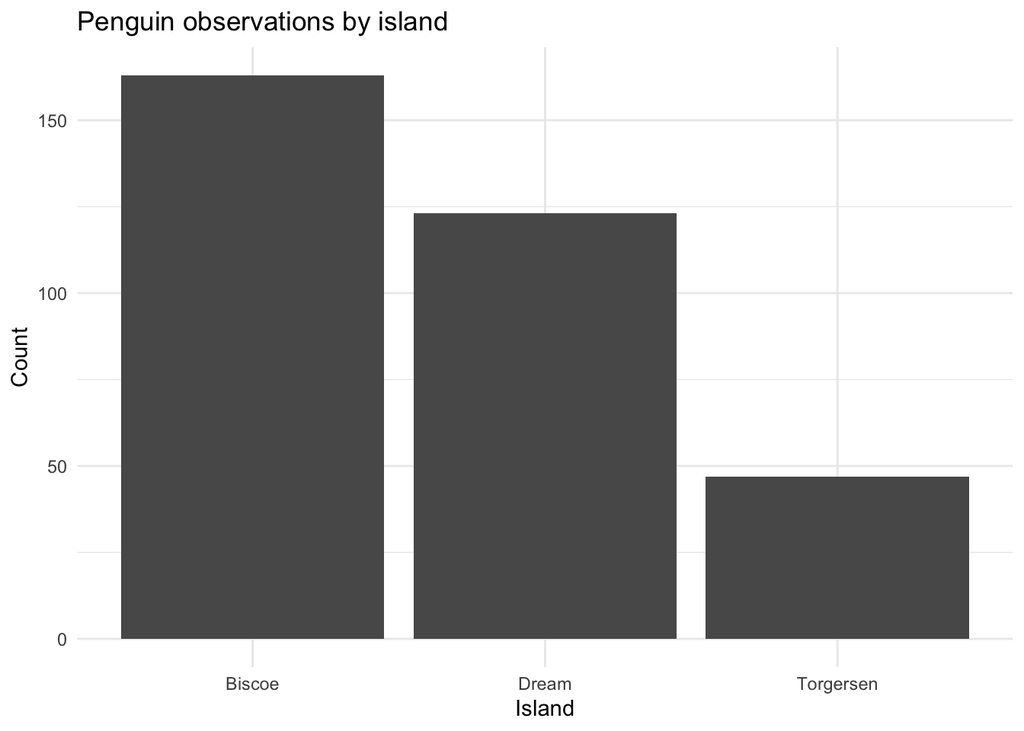

````r
``` r
ggplot(penguins, aes(x = island)) +
  geom_bar() +
  labs(
    title = "Penguin observations by island",
    x = "Island",
    y = "Count"
  ) + theme_minimal()
````

# Q2: # What is the general shape of the distribution (normal? bimodal?) # Answer: In this histogram, the general shape is bimodal because it doesn’t have one clear peak. # How does bin number change what you see? # Answer: A lower bins shows a more smoother and blocky and individual peaks seem to merge better. Higher bins show higher fine details and looks more jagged. # How does the distribution differ between species? Do they all have the same approximate mean? # Answer: Adelie have the lowest body mass, chinstrap have intermediate body mass, and gentoo penguins have the highest body mass. No, the species do not have the same approximate mean.

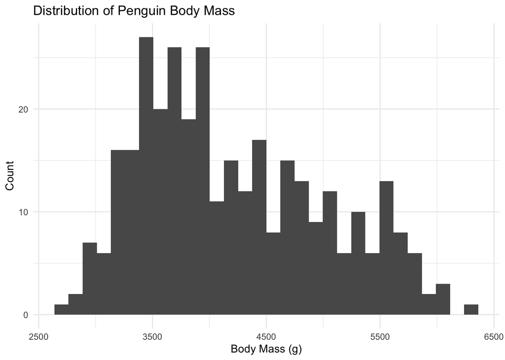

```r
ggplot(penguins, aes(x = body_mass_g)) +
  geom_histogram(bins = 30) +
  labs(
    title = "Distribution of Penguin Body Mass", x = "Body Mass (g)", y = "Count") + theme_minimal()
```

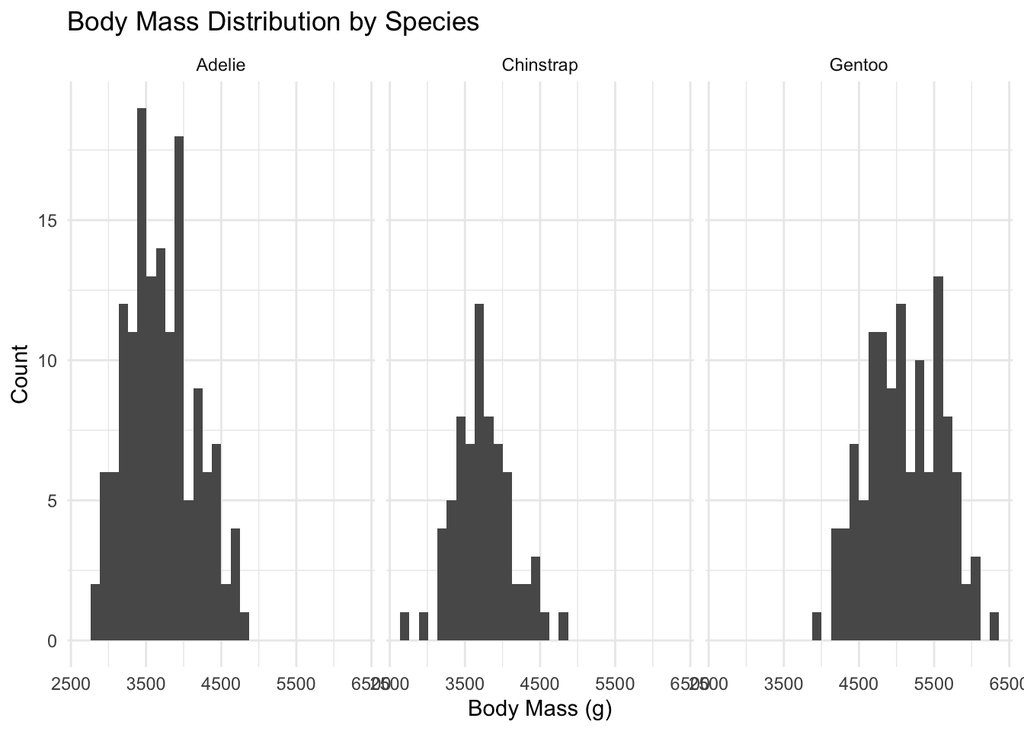

```r
ggplot(penguins, aes(x = body_mass_g)) +
  geom_histogram(bins = 30) +
  facet_wrap(~ species) +
  labs(
    title = "Body Mass Distribution by Species", x = "Body Mass (g)", y = "Count" ) + theme_minimal()
```

#Q3 #Which species has the longest flippers (typical value)? # Answer: Gentoo penguins have the highest flipper length.

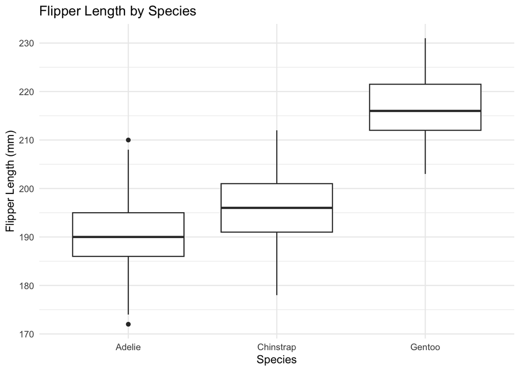

```r
ggplot(penguins, aes(x = species, y = flipper_length_mm)) +
  geom_boxplot() +
  labs(
    title = "Flipper Length by Species",
    x = "Species",
    y = "Flipper Length (mm)"
  ) +
  theme_minimal()
```

# Do males and females differ? # Answer: Yes, males have a higher body mass.

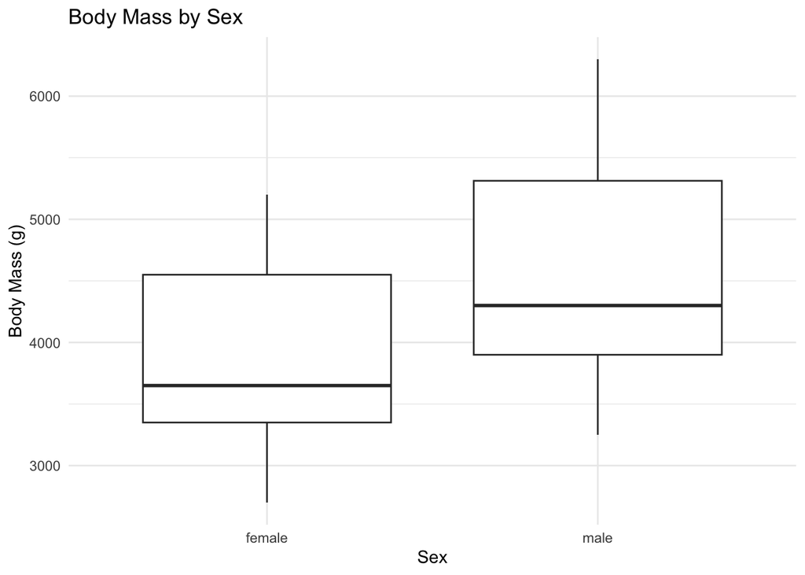

```r
ggplot(penguins, aes(x = sex, y = body_mass_g)) +
  geom_boxplot() +
  labs(
    title = "Body Mass by Sex",
    x = "Sex",
    y = "Body Mass (g)"
  ) +
  theme_minimal()
```

# Does it help readability? # Answer: Yes, it adds colors.

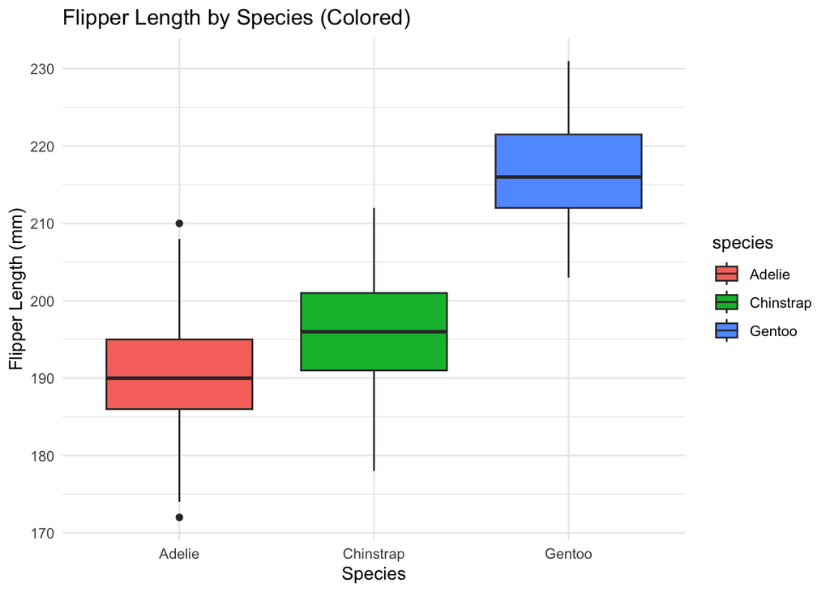

```r
ggplot(penguins, aes(x = species, y = flipper_length_mm, fill = species)) +
  geom_boxplot() +
  labs(
    title = "Flipper Length by Species (Colored)",
    x = "Species",
    y = "Flipper Length (mm)"
  ) +
  theme_minimal()
```

# Q4 # Is the relationship positive, negative, or unclear? # Answer: The relationship is unclear.

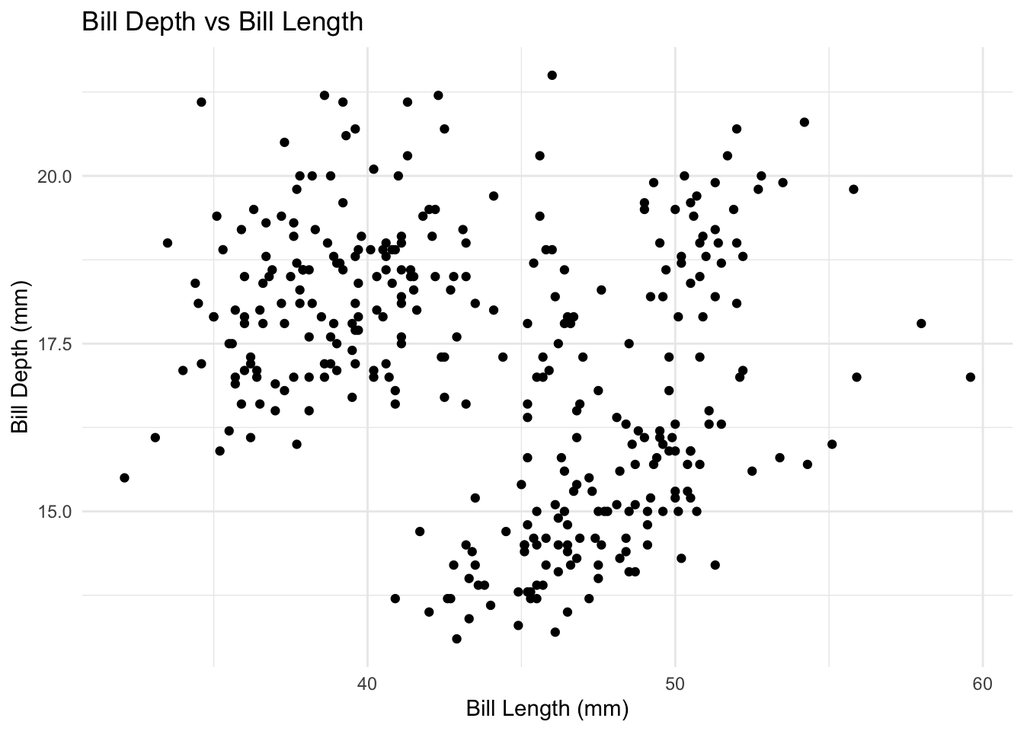

```r
ggplot(penguins, aes(x = bill_length_mm, y = bill_depth_mm)) +
  geom_point() +
  labs(
    title = "Bill Depth vs Bill Length",
    x = "Bill Length (mm)",
    y = "Bill Depth (mm)"
  ) +
  theme_minimal()
```

# Does that change your interpretation? # Answer: Yes, because there’s color.

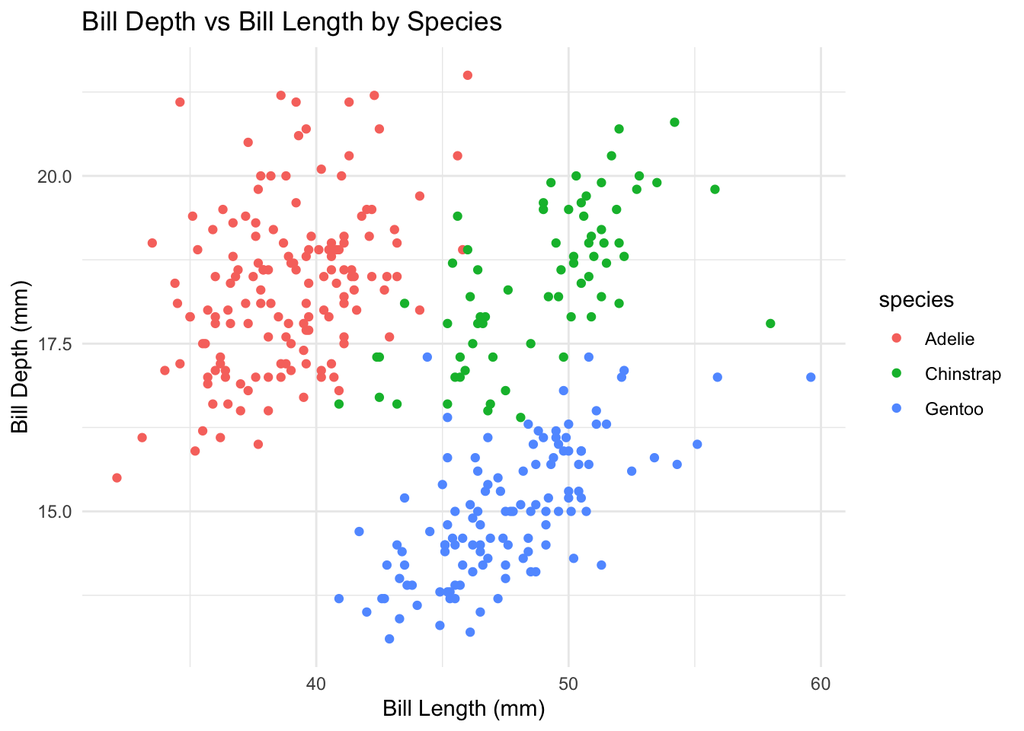

```r
ggplot(penguins, aes(x = bill_length_mm, y = bill_depth_mm, color = species)) +
  geom_point() +
  labs(
    title = "Bill Depth vs Bill Length by Species",
    x = "Bill Length (mm)",
    y = "Bill Depth (mm)"
  ) +
  theme_minimal()
```

# Does the line fit the data well? # Answer: Yes, the line does fit the data well.

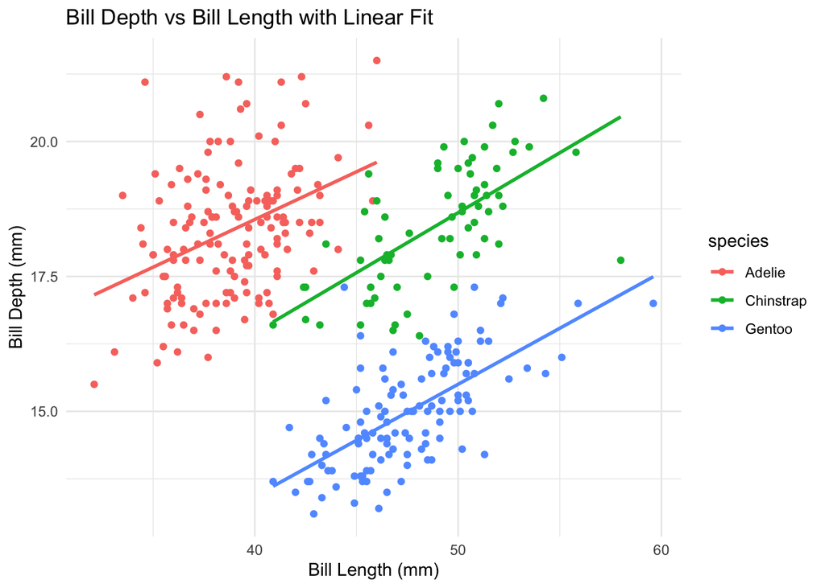

```r
ggplot(penguins, aes(x = bill_length_mm, y = bill_depth_mm, color = species)) +
  geom_point() +
  geom_smooth(method = "lm", se = FALSE) +
  labs(
    title = "Bill Depth vs Bill Length with Linear Fit",
    x = "Bill Length (mm)",
    y = "Bill Depth (mm)"
 ) +
  theme_minimal()
```

# Q5 # Which species shows the strongest relationship? # Answer: Gentoo shows the strongest relationship.

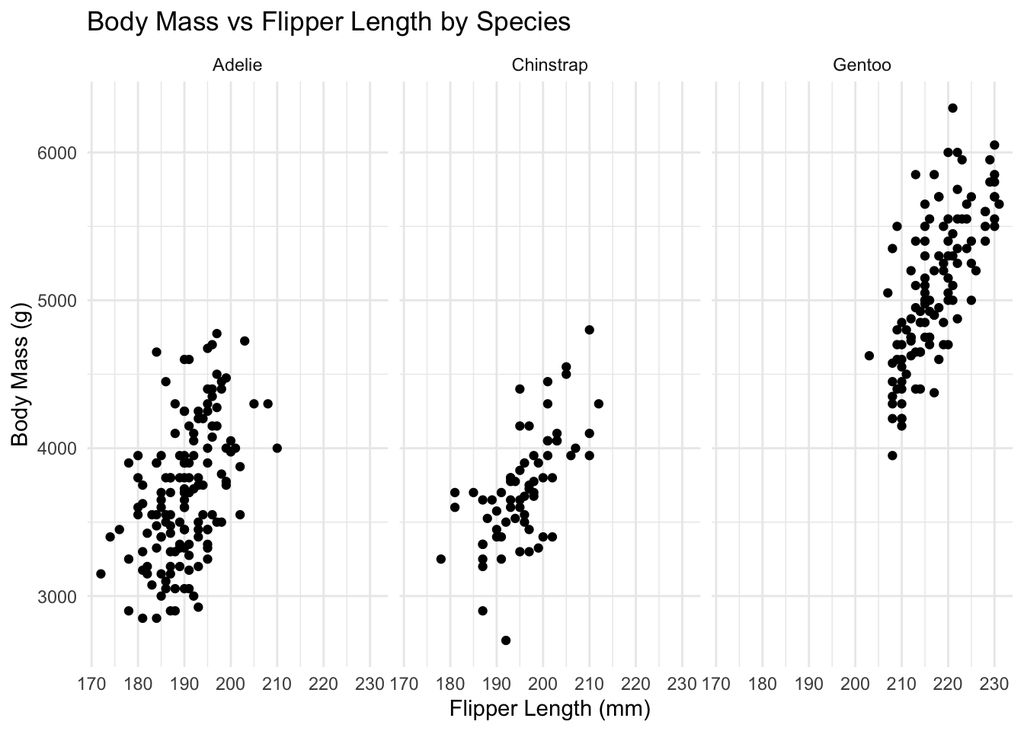

```r
ggplot(penguins, aes(x = flipper_length_mm, y = body_mass_g)) +
  geom_point() +
  facet_wrap(~ species) +
  labs(
    title = "Body Mass vs Flipper Length by Species",
    x = "Flipper Length (mm)",
    y = "Body Mass (g)"
  ) +
  theme_minimal()
```

# What patterns appear? # Answer: Males have a higher body mass and gentoos are heavier.

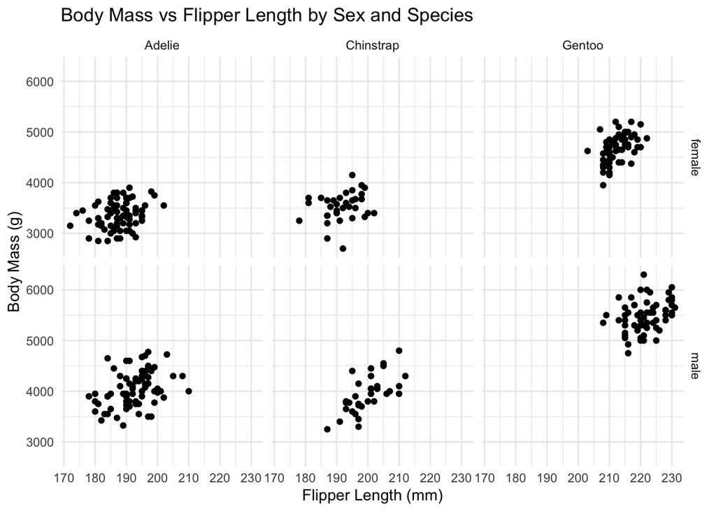

```r
ggplot(penguins, aes(x = flipper_length_mm, y = body_mass_g)) +
  geom_point() +
  facet_grid(sex ~ species) +
  labs(
    title = "Body Mass vs Flipper Length by Sex and Species",
    x = "Flipper Length (mm)",
    y = "Body Mass (g)"
  ) +
  theme_minimal()
```

#Q6

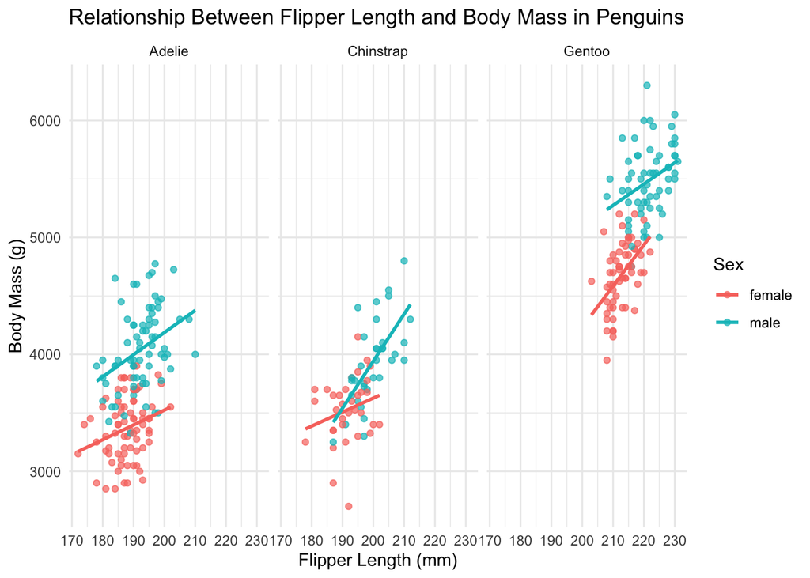

```r
ggplot(penguins, aes(x = flipper_length_mm, y = body_mass_g, color = sex)) +geom_point(alpha = 0.7) +geom_smooth(method = "lm", se = FALSE) +facet_wrap(~ species) + labs(
    title = "Relationship Between Flipper Length and Body Mass in Penguins",
 x = "Flipper Length (mm)",y = "Body Mass (g)",color = "Sex") + theme_minimal()
```

#Q7 # What was the most fun or interesting part of this exercise? Which part was most confusing or difficult? # Answer: Looking at the different colors and plots were fun! The syntax of ggplots was confusing.

# title: “Lecture 07: Regular Expressions”

# author: “Helennah Tran”

# date: “2026-01-29”

# output: html_document

# Q1: Run each of the below commands and write (in words) what each one does.

# Answer: The first command checks the word adelie appears in the species column and returns TRUE or FALSE for each row.

```r
str_detect(penguins_messy$species_messy, "adelie")
```

```
##   [1]  TRUE  TRUE  TRUE  TRUE  TRUE  TRUE  TRUE  TRUE  TRUE  TRUE  TRUE  TRUE
##  [13]  TRUE  TRUE  TRUE  TRUE  TRUE  TRUE  TRUE  TRUE  TRUE  TRUE  TRUE  TRUE
##  [25]  TRUE  TRUE  TRUE  TRUE  TRUE  TRUE  TRUE  TRUE  TRUE  TRUE  TRUE  TRUE
##  [37]  TRUE  TRUE  TRUE  TRUE  TRUE  TRUE  TRUE  TRUE  TRUE  TRUE  TRUE  TRUE
##  [49]  TRUE  TRUE  TRUE  TRUE  TRUE  TRUE  TRUE  TRUE  TRUE  TRUE  TRUE  TRUE
##  [61]  TRUE  TRUE  TRUE  TRUE  TRUE  TRUE  TRUE  TRUE  TRUE  TRUE  TRUE  TRUE
##  [73]  TRUE  TRUE  TRUE  TRUE  TRUE  TRUE  TRUE  TRUE  TRUE  TRUE  TRUE  TRUE
##  [85]  TRUE  TRUE  TRUE  TRUE  TRUE  TRUE  TRUE  TRUE  TRUE  TRUE  TRUE  TRUE
##  [97]  TRUE  TRUE  TRUE  TRUE  TRUE  TRUE  TRUE  TRUE  TRUE  TRUE  TRUE  TRUE
## [109]  TRUE  TRUE  TRUE  TRUE  TRUE  TRUE  TRUE  TRUE  TRUE  TRUE  TRUE  TRUE
## [121]  TRUE  TRUE  TRUE  TRUE  TRUE  TRUE  TRUE  TRUE  TRUE  TRUE  TRUE  TRUE
## [133]  TRUE  TRUE  TRUE  TRUE  TRUE  TRUE  TRUE  TRUE  TRUE  TRUE  TRUE  TRUE
## [145]  TRUE  TRUE  TRUE  TRUE  TRUE  TRUE  TRUE  TRUE FALSE FALSE FALSE FALSE
## [157] FALSE FALSE FALSE FALSE FALSE FALSE FALSE FALSE FALSE FALSE FALSE FALSE
## [169] FALSE FALSE FALSE FALSE FALSE FALSE FALSE FALSE FALSE FALSE FALSE FALSE
## [181] FALSE FALSE FALSE FALSE FALSE FALSE FALSE FALSE FALSE FALSE FALSE FALSE
## [193] FALSE FALSE FALSE FALSE FALSE FALSE FALSE FALSE FALSE FALSE FALSE FALSE
## [205] FALSE FALSE FALSE FALSE FALSE FALSE FALSE FALSE FALSE FALSE FALSE FALSE
## [217] FALSE FALSE FALSE FALSE FALSE FALSE FALSE FALSE FALSE FALSE FALSE FALSE
## [229] FALSE FALSE FALSE FALSE FALSE FALSE FALSE FALSE FALSE FALSE FALSE FALSE
## [241] FALSE FALSE FALSE FALSE FALSE FALSE FALSE FALSE FALSE FALSE FALSE FALSE
## [253] FALSE FALSE FALSE FALSE FALSE FALSE FALSE FALSE FALSE FALSE FALSE FALSE
## [265] FALSE FALSE FALSE FALSE FALSE FALSE FALSE FALSE FALSE FALSE FALSE FALSE
## [277] FALSE FALSE FALSE FALSE FALSE FALSE FALSE FALSE FALSE FALSE FALSE FALSE
## [289] FALSE FALSE FALSE FALSE FALSE FALSE FALSE FALSE FALSE FALSE FALSE FALSE
## [301] FALSE FALSE FALSE FALSE FALSE FALSE FALSE FALSE FALSE FALSE FALSE FALSE
## [313] FALSE FALSE FALSE FALSE FALSE FALSE FALSE FALSE FALSE FALSE FALSE FALSE
## [325] FALSE FALSE FALSE FALSE FALSE FALSE FALSE FALSE FALSE FALSE FALSE FALSE
## [337] FALSE FALSE FALSE FALSE FALSE FALSE FALSE FALSE
```

# Answer: The second command removes all question marks from the sex column.

```r
str_replace_all(penguins_messy$sex_messy, "\\?", "")
```

```
##   [1] "M" "f" "f" NA  "f" "M" "f" "M" NA  NA  NA  NA  "f" "M" "M" "f" "f" "M"
##  [19] "f" "M" "f" "M" "f" "M" "M" "f" "M" "f" "f" "M" "f" "M" "f" "M" "f" "M"
##  [37] "M" "f" "f" "M" "f" "M" "f" "M" "f" "M" "M" NA  "f" "M" "f" "M" "f" "M"
##  [55] "f" "M" "f" "M" "f" "M" "f" "M" "f" "M" "f" "M" "f" "M" "f" "M" "f" "M"
##  [73] "f" "M" "f" "M" "f" "M" "f" "M" "f" "M" "f" "M" "f" "M" "M" "f" "M" "f"
##  [91] "f" "M" "f" "M" "f" "M" "f" "M" "f" "M" "f" "M" "f" "M" "f" "M" "f" "M"
## [109] "f" "M" "f" "M" "f" "M" "f" "M" "f" "M" "f" "M" "f" "M" "f" "M" "f" "M"
## [127] "f" "M" "f" "M" "f" "M" "f" "M" "f" "M" "f" "M" "f" "M" "f" "M" "f" "M"
## [145] "f" "M" "M" "f" "f" "M" "f" "M" "f" "M" "f" "M" "M" "f" "f" "M" "f" "M"
## [163] "f" "M" "f" "M" "f" "M" "f" "M" "f" "M" "M" "f" "f" "M" "f" "M" NA  "M"
## [181] "f" "M" "M" "f" "f" "M" "f" "M" "f" "M" "f" "M" "f" "M" "f" "M" "M" "f"
## [199] "f" "M" "f" "M" "f" "M" "f" "M" "f" "M" "f" "M" "f" "M" "f" "M" "f" "M"
## [217] "f" "M" NA  "M" "f" "M" "f" "M" "M" "f" "f" "M" "f" "M" "f" "M" "f" "M"
## [235] "f" "M" "f" "M" "f" "M" "f" "M" "f" "M" "f" "M" "f" "M" "M" "f" "f" "M"
## [253] "f" "M" "f" "M" NA  "M" "f" "M" "f" "M" "f" "M" "f" "M" "f" "M" NA  "M"
## [271] "f" NA  "f" "M" "f" "M" "f" "M" "M" "f" "M" "f" "f" "M" "f" "M" "f" "M"
## [289] "f" "M" "f" "M" "M" "f" "f" "M" "f" "M" "f" "M" "f" "M" "f" "M" "f" "M"
## [307] "f" "M" "f" "M" "M" "f" "f" "M" "f" "M" "M" "f" "M" "f" "f" "M" "f" "M"
## [325] "M" "f" "f" "M" "f" "M" "f" "M" "f" "M" "M" "f" "M" "f" "f" "M" "f" "M"
## [343] "M" "f"
```

# Answer: The third command removes extra spaces and collapses repeated whitespace in the island column.

```r
str_squish(penguins_messy$island_messy)
```

```
##   [1] "Torgersen" "Torgersen" "Torgersen" "Torgersen" "Torgersen" "Torgersen"
##   [7] "Torgersen" "Torgersen" "Torgersen" "Torgersen" "Torgersen" "Torgersen"
##  [13] "Torgersen" "Torgersen" "Torgersen" "Torgersen" "Torgersen" "Torgersen"
##  [19] "Torgersen" "Torgersen" "BIS-COE"   "BIS-COE"   "BIS-COE"   "BIS-COE"
##  [25] "BIS-COE"   "BIS-COE"   "BIS-COE"   "BIS-COE"   "BIS-COE"   "BIS-COE"
##  [31] "Dream"     "Dream"     "Dream"     "Dream"     "Dream"     "Dream"
##  [37] "Dream"     "Dream"     "Dream"     "Dream"     "Dream"     "Dream"
##  [43] "Dream"     "Dream"     "Dream"     "Dream"     "Dream"     "Dream"
##  [49] "Dream"     "Dream"     "BIS-COE"   "BIS-COE"   "BIS-COE"   "BIS-COE"
##  [55] "BIS-COE"   "BIS-COE"   "BIS-COE"   "BIS-COE"   "BIS-COE"   "BIS-COE"
##  [61] "BIS-COE"   "BIS-COE"   "BIS-COE"   "BIS-COE"   "BIS-COE"   "BIS-COE"
##  [67] "BIS-COE"   "BIS-COE"   "Torgersen" "Torgersen" "Torgersen" "Torgersen"
##  [73] "Torgersen" "Torgersen" "Torgersen" "Torgersen" "Torgersen" "Torgersen"
##  [79] "Torgersen" "Torgersen" "Torgersen" "Torgersen" "Torgersen" "Torgersen"
##  [85] "Dream"     "Dream"     "Dream"     "Dream"     "Dream"     "Dream"
```

[output cut: 43 more lines]

# Q2

# Answer: The number is 316.

```r
penguins_messy <- penguins_messy %>%
  mutate(valid_id = str_detect(sample_id, "PAL-[0-9]{3}"))

penguins_messy %>%
  pull(valid_id) %>%
  sum()
```

```
## [1] 316
```

# Q3

```r
penguins_messy <- penguins_messy %>%
  filter(valid_id)
head(penguins_messy)
```

```
##   species_messy island_messy sex_messy sample_id
## 1        adelie  Torgersen\t         M   PAL-535
## 2        adelie  Torgersen\t        f?   PAL-442
## 3        adelie  Torgersen\t        f?   PAL-668
## 4        adelie  Torgersen\t      <NA>   PAL-920
## 5        adelie  Torgersen\t        f?   PAL-223
## 6        adelie  Torgersen\t         M   PAL-899
##                                   file_name
## 1 2024-01-14_Torgersen\t_adelie_PAL-535.csv
## 2 2024-01-17_Torgersen\t_adelie_PAL-442.csv
## 3 2024-01-08_Torgersen\t_adelie_PAL-668.csv
## 4 2024-01-26_Torgersen\t_adelie_PAL-920.csv
## 5 2024-01-06_Torgersen\t_adelie_PAL-223.csv
## 6 2024-01-08_Torgersen\t_adelie_PAL-899.csv
##                                                    notes valid_id
## 1 id=PAL-535; island=Torgersen\t; sp=adelie; bill=39.1mm     TRUE
## 2 id=PAL-442; island=Torgersen\t; sp=adelie; bill=39.5mm     TRUE
## 3 id=PAL-668; island=Torgersen\t; sp=adelie; bill=40.3mm     TRUE
## 4   id=PAL-920; island=Torgersen\t; sp=adelie; bill=NAmm     TRUE
## 5 id=PAL-223; island=Torgersen\t; sp=adelie; bill=36.7mm     TRUE
## 6 id=PAL-899; island=Torgersen\t; sp=adelie; bill=39.3mm     TRUE
```

# Q4

```r
penguins_messy <- penguins_messy %>%
  mutate(
    file_date = str_extract(file_name, "[0-9]{4}-[0-9]{2}-[0-9]{2}"),
    file_id   = str_extract(file_name, "PAL-[0-9]{3}")
  )

head(penguins_messy, 10)
```

```
##    species_messy island_messy sex_messy sample_id
## 1         adelie  Torgersen\t         M   PAL-535
## 2         adelie  Torgersen\t        f?   PAL-442
## 3         adelie  Torgersen\t        f?   PAL-668
## 4         adelie  Torgersen\t      <NA>   PAL-920
## 5         adelie  Torgersen\t        f?   PAL-223
## 6         adelie  Torgersen\t         M   PAL-899
## 7         adelie  Torgersen\t        f?   PAL-268
## 8         adelie  Torgersen\t         M   PAL-139
## 9         adelie  Torgersen\t      <NA>   PAL-847
## 10        adelie  Torgersen\t      <NA>   PAL-238
##                                    file_name
## 1  2024-01-14_Torgersen\t_adelie_PAL-535.csv
## 2  2024-01-17_Torgersen\t_adelie_PAL-442.csv
## 3  2024-01-08_Torgersen\t_adelie_PAL-668.csv
```

[output cut: 29 more lines]

# Q5

```r
penguins_messy <- penguins_messy %>%
  mutate(island = str_squish(island_messy))

unique(penguins_messy$island)
```

```
## [1] "Torgersen" "BIS-COE"   "Dream"
```

# Q6

```r
penguins_messy <- penguins_messy %>%
  mutate(sex = sex_messy %>%str_replace_all("\\?", "") %>%str_to_upper() )
unique(penguins_messy$sex)
```

```
## [1] "M" "F" NA
```

# Q7

```r
penguins_messy <- penguins_messy %>%
  mutate(bill_mm = notes %>%str_replace_all(".*bill=", "") %>%str_replace_all("mm", "") %>%as.numeric())
head(penguins_messy$bill_mm, 10)
```

```
##  [1] 39.1 39.5 40.3   NA 36.7 39.3 38.9 39.2 34.1 42.0
```

#Q8 # What was the most fun or interesting part of this exercise? Which part was most confusing or difficult? # Answer: The most interesting part was cleaning up messy data with regular expressions. The most confusing part was how to write special characters and regular expressions. # Do you feel like you have a general idea of how regular expressions are used? # I have a general idea but I need more practice.

# title: “Lecture 08 – The Data Wrangling Survival Kit”

# author: “Helennah Tran”

# date: “2026-02-03”

# output: html_document

```r
penguins_clean <- penguins %>%drop_na(bill_length_mm, sex)

nrow(penguins)
```

```
## [1] 333
```

```r
nrow(penguins_clean)
```

```
## [1] 333
```

#Q2 Why can duplicates mess up summary statitics and plots? # Answer: Duplicates can affect summary results because repeated rows are counted more than once.

```r
penguins_dup <- penguins_clean %>%bind_rows(slice_sample(penguins_clean, n = 30, replace = TRUE)
  )
nrow(penguins_dup)
```

```
## [1] 363
```

```r
penguins_nodup <- penguins_dup %>%distinct()

nrow(penguins_nodup)
```

```
## [1] 333
```

#Q3 How many columns are in the resulting data frame? # Answer: There are 8 columns.

```r
penguins_selected <- penguins_clean %>%
  select(species,island,sex,where(is.numeric))
ncol(penguins_selected)
```

```
## [1] 8
```

#Q4

```r
penguins_clean %>%
  select(starts_with("bill"))
```

```
## # A tibble: 333 × 2
##    bill_length_mm bill_depth_mm
##             <dbl>         <dbl>
##  1           39.1          18.7
##  2           39.5          17.4
##  3           40.3          18
##  4           36.7          19.3
##  5           39.3          20.6
##  6           38.9          17.8
##  7           39.2          19.6
##  8           41.1          17.6
##  9           38.6          21.2
## 10           34.6          21.1
## # ℹ 323 more rows
```

```r
penguins_clean %>%
  select(ends_with("_mm"))
```

```
## # A tibble: 333 × 3
##    bill_length_mm bill_depth_mm flipper_length_mm
##             <dbl>         <dbl>             <int>
##  1           39.1          18.7               181
##  2           39.5          17.4               186
##  3           40.3          18                 195
##  4           36.7          19.3               193
##  5           39.3          20.6               190
##  6           38.9          17.8               181
##  7           39.2          19.6               195
##  8           41.1          17.6               182
##  9           38.6          21.2               191
## 10           34.6          21.1               198
## # ℹ 323 more rows
```

```r
penguins_clean %>%
  select(matches("bill|flipper"))
```

```
## # A tibble: 333 × 3
##    bill_length_mm bill_depth_mm flipper_length_mm
##             <dbl>         <dbl>             <int>
##  1           39.1          18.7               181
##  2           39.5          17.4               186
##  3           40.3          18                 195
##  4           36.7          19.3               193
##  5           39.3          20.6               190
##  6           38.9          17.8               181
##  7           39.2          19.6               195
##  8           41.1          17.6               182
##  9           38.6          21.2               191
## 10           34.6          21.1               198
## # ℹ 323 more rows
```

#Q5 Why is across(where(is.numeric), …) better than typing out every numeric column name by hand? # Answer: Using across(where(is.numeric), …) is better because it automatically applies the calculation to all numeric columns.

```r
penguins_clean %>%group_by(species) %>%
  summarise(across(where(is.numeric), mean))
```

```
## # A tibble: 3 × 6
##   species   bill_length_mm bill_depth_mm flipper_length_mm body_mass_g  year
##   <fct>              <dbl>         <dbl>             <dbl>       <dbl> <dbl>
## 1 Adelie              38.8          18.3              190.       3706. 2008.
## 2 Chinstrap           48.8          18.4              196.       3733. 2008.
## 3 Gentoo              47.6          15.0              217.       5092. 2008.
```

#Q6

```r
penguins_clean <- penguins_clean %>%
  mutate(bill_length = case_when(
      bill_length_mm < 40 ~ "short",
      bill_length_mm < 50 ~ "medium",
      bill_length_mm >= 50 ~ "long"
    )
  )
```

#Q7 What is the number of columns in penguins_instrumented and penguins_clean? # penguins_clean has 9 columns. # penguins_instrumented has 12 columns.

```r
instrument_meta <- tibble(instrument_id = c("caliper_A", "caliper_B", "caliper_C"), calibration_mm = c(0.2, 0.5, 1.0), manufacturer = c("Mitutoyo", "Fowler", "Generic")
)
penguins_instrumented <- penguins_clean %>%drop_na(bill_length_mm) %>%mutate(instrument_id = case_when(year == 2007 ~ "caliper_A",year == 2008 ~ "caliper_B",year == 2009 ~ "caliper_C")) %>%left_join(instrument_meta, by = "instrument_id")
ncol(penguins_clean)
```

```
## [1] 9
```

```r
ncol(penguins_instrumented)
```

```
## [1] 12
```

#Q8 # What was the most fun or interesting part of this exercise? Which part was most confusing or difficult? # Answer: The most interesting part was creating new variables. The most confusing part was keeping track of how each step changed the number of rows or columns after filtering and joining. # Do you feel like these general “survival tips” will be useful in your data analyses in the future? # Answer: Yes, it will be useful in data analyses in the future because it provides a clear way to show data, variables, results, and combine everything.